# 732A73: Bayesian Learning

Computer Lab 4

Oriol Garrobé, Dávid Hrabovszki

17 May 2020

# Question 1. Time series models in Stan

### (a)

We are asked to develop a simulator from the AR(1)-process,
$$x_t=\mu+\phi(x_{t-1}-\mu)+\epsilon_t,\quad \epsilon_t \stackrel{iid}\sim N(0,\sigma^2),$$
for the given values: $\mu=10$, $\sigma^2=2$ and $\phi\in(-1,1)$. The code of the simulater can be seen in the Appendix.

From this point we are asked to generate 200 values of $x_t$. In Figure it can be seen one simulation for $\phi=1$. The parameter $\phi$ determines how the current value of $x_t$ depends on the previous value. If $\phi>0$ then they are positively correlated, if $\phi<0$ they are negatively correlated and if $\phi=0$ they are not correlated at all.

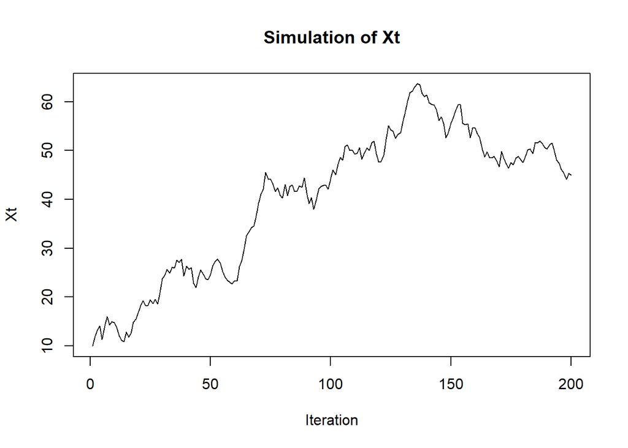

AR(1)-process simulation